# hw4

Tariq Anwar

February 16, 2016

## Problem1

Team Member: Tariq Anwar

Project Description: U.S Dept of Education: College Scorecard. Source: https://www.kaggle.com/kaggle/college-scorecard I am planning to work on this dataset. It was published few months ago as part of Kaggle online competition in Data Science.

## Problem 2.a

The participant objection might hold true because merely looking at the results provided by regresssion analysis such as coefficent of determination and correlation coefficent often mislead the conclusion.It is therefore necessary to study the domain also which might reveal better information.

Although , the coefficient of determination $r^2$ and correlation coefficient r quantify the strength of lineat relationship . It is possible that $r^2= 0% and r =0$, suggesting that there is no relationship between hardness of plastic (Y) and elapsed time since moulding(X) and yet a perfect curved relationship exists between these variables.

Even if we get higher coefficient of determination between two variables it does not mean that estimated regression line fits the data well,another function might describe data well.

And the most important of all point is correlation does not imply causation.There are many possible reason as to why there is an association between X and Y.So to reach the conclusion designed experiment and sound scientific justification is required.

## Problem 2.b

Yes. The equation is true for ith data point in the population

A simple regression model averaged over a set of data points can be summarized with the below formula: $E(y)= \beta_0 +\beta_1x$

The above formula is population regression line and it summarizes the trend in the population between the predictor variable and the mean of the population .

The equation for average of i-th data point can be represented by the below formula. $E(y)= \beta_0 +\beta_1x + e_i$ where $e_i$ represent the error.

## Problem 2.c

The statement that for least square method to be fully valid, it is required that distribution of Y be normal does not holds true because the least square method depends on the error variance from best fit line and on the assumption that mean of the predictor variable is linear function of explanatory variables.

## Problem 2.d

It is not necessarily that in a regression model fitted to set of n cases by least square method the summation of random error will be 0. Random error is related to popualation and the residuals are related to samples.Residuals are estimates to errors.However these both terms can be used interchangebly so the summation may or may not be 0.

## Problem 2.e

```r
ldata<- matrix(data = c( 199.0,205.0,196.0,200.0,218.0,220.0,215.0,223.0,237.0,234.0,235.0,230.0,250.0,248.0,253.0,246.0,16.0,16.0,16.0,16.0,24.0,24.0,24.0,24.0,32.0,32.0,32.0,32.0,40.0,40.0,40.0,40.0), nrow=16 , ncol=2)

ldata<-data.frame(ldata)
colnames(ldata)<- c("Y","X")
#ldata
plot(ldata$X,ldata$Y)
llm = lm(Y~X,data=ldata)


sumr<-summary(llm)
sumr
```

```
##
## Call:
## lm(formula = Y ~ X, data = ldata)
##
## Residuals:
##     Min      1Q  Median      3Q     Max
## -5.1500 -2.2188  0.1625  2.6875  5.5750
##
## Coefficients:
##              Estimate Std. Error t value Pr(>|t|)
## (Intercept) 168.60000    2.65702   63.45  < 2e-16 ***
## X             2.03438    0.09039   22.51 2.16e-12 ***
## ---
## Signif. codes:  0 '***' 0.001 '**' 0.01 '*' 0.05 '.' 0.1 ' ' 1
##
## Residual standard error: 3.234 on 14 degrees of freedom
## Multiple R-squared:  0.9731, Adjusted R-squared:  0.9712
## F-statistic: 506.5 on 1 and 14 DF,  p-value: 2.159e-12
```

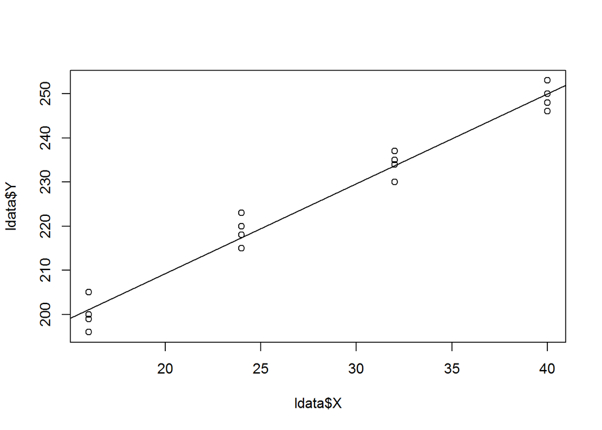

```r
abline(llm)
```

The estimated regression model is $Y = 168.6 + 2.03X$

#### Point estimate of mean hardness of 40

```r
Y = 168.6 + 2.03*(40)
Y
```

```
## [1] 249.8
```

### Problem 2.f

```r
resid = resid(llm)
#List of residuals
resid
```

```
##      1      2      3      4      5      6      7      8      9     10
## -2.150  3.850 -5.150 -1.150  0.575  2.575 -2.425  5.575  3.300  0.300
##     11     12     13     14     15     16
##  1.300 -3.700  0.025 -1.975  3.025 -3.975
```

```r
sum(resid)
```

```
## [1] -1.998401e-15
```

```r
##Sum is almost 0

##Estimation (b)

MSE = mean(sumr$residuals^2)
MSE
```

```
## [1] 9.151562
```

```r
#sigma
mean(sumr$residuals)
```

```
## [1] -1.249001e-16
```

```r
#The unit will be same as that of Y i.e hardness in brinell
```

## Problem 3

```r
library(tidyr, quietly = TRUE)
library(dplyr, quietly = TRUE)
sestates <- read.csv("http://samplecsvs.s3.amazonaws.com/Sacramentorealestatetrans
actions.csv", header = TRUE, stringsAsFactors = FALSE)
head(sestates)
```

```
##               street       city   zip state beds baths sq__ft        type
## 1       3526 HIGH ST SACRAMENTO 95838    CA    2     1    836 Residential
## 2        51 OMAHA CT SACRAMENTO 95823    CA    3     1   1167 Residential
## 3     2796 BRANCH ST SACRAMENTO 95815    CA    2     1    796 Residential
## 4   2805 JANETTE WAY SACRAMENTO 95815    CA    2     1    852 Residential
## 5    6001 MCMAHON DR SACRAMENTO 95824    CA    2     1    797 Residential
## 6 5828 PEPPERMILL CT SACRAMENTO 95841    CA    3     1   1122       Condo
##                      sale_date price latitude longitude
## 1 Wed May 21 00:00:00 EDT 2008 59222 38.63191 -121.4349
## 2 Wed May 21 00:00:00 EDT 2008 68212 38.47890 -121.4310
## 3 Wed May 21 00:00:00 EDT 2008 68880 38.61830 -121.4438
## 4 Wed May 21 00:00:00 EDT 2008 69307 38.61684 -121.4391
## 5 Wed May 21 00:00:00 EDT 2008 81900 38.51947 -121.4358
## 6 Wed May 21 00:00:00 EDT 2008 89921 38.66260 -121.3278
```

```r
## replace the column sale date

tidy_data<- tidyr::separate (sestates, sale_date, c ("day_week", "month", "day_month" ))
head(tidy_data)
```

```
##               street       city   zip state beds baths sq__ft        type
## 1       3526 HIGH ST SACRAMENTO 95838    CA    2     1    836 Residential
## 2        51 OMAHA CT SACRAMENTO 95823    CA    3     1   1167 Residential
## 3     2796 BRANCH ST SACRAMENTO 95815    CA    2     1    796 Residential
## 4   2805 JANETTE WAY SACRAMENTO 95815    CA    2     1    852 Residential
## 5    6001 MCMAHON DR SACRAMENTO 95824    CA    2     1    797 Residential
## 6 5828 PEPPERMILL CT SACRAMENTO 95841    CA    3     1   1122       Condo
##   day_week month day_month price latitude longitude
## 1      Wed   May        21 59222 38.63191 -121.4349
## 2      Wed   May        21 68212 38.47890 -121.4310
## 3      Wed   May        21 68880 38.61830 -121.4438
## 4      Wed   May        21 69307 38.61684 -121.4391
## 5      Wed   May        21 81900 38.51947 -121.4358
## 6      Wed   May        21 89921 38.66260 -121.3278
```

```r
## b. What's the top 10 cities with the most transactions?

byTrans<- group_by(sestates,city)
sumTrans<- summarize(byTrans,count=n())
sumTrans <- dplyr::arrange(sumTrans, desc(count))
dplyr::top_n(sumTrans, 10)
```

```
## Source: local data frame [10 x 2]
##
##               city count
##              (chr) (int)
## 1       SACRAMENTO   439
## 2        ELK GROVE   114
## 3          LINCOLN    72
## 4        ROSEVILLE    48
## 5   CITRUS HEIGHTS    35
## 6         ANTELOPE    33
## 7   RANCHO CORDOVA    28
## 8  EL DORADO HILLS    23
## 9             GALT    21
## 10 NORTH HIGHLANDS    21
```

```r
##c. What's the accumulated number of transactions from May 15 to May 21 in city ELK GROVE?
filtered <- dplyr::filter(tidy_data, city=="ELK GROVE")
bydate<- dplyr::filter(filtered,month=="May" ,day_month>=15 ,day_month<=21 )
sumTrans<- group_by(bydate,day_month,month)
sumTrans<- summarize(sumTrans,n_trans=n())
sumTrans<-mutate(sumTrans,n_cumtrans=sum(n_trans))
sumTrans
```

```
## Source: local data frame [5 x 4]
## Groups: day_month [5]
##
##   day_month month n_trans n_cumtrans
##       (chr) (chr)   (int)      (int)
## 1        15   May      13         13
## 2        16   May      28         28
## 3        19   May      19         19
## 4        20   May      22         22
## 5        21   May      32         32
```

```r
##d. For each type of house (Condo, Multi-Family, and Residential), what's the highest 3 transaction prices? In which cities?

as<- tidy_data %>% group_by(type) %>% arrange(desc(price)) %>% top_n(3,price)
as<-select(as,type,city,price)
as<-dplyr::filter(as, type != "Unkown")
as
```

```
## Source: local data frame [9 x 3]
## Groups: type [3]
##
##           type            city  price
##          (chr)           (chr)  (int)
## 1        Condo      SACRAMENTO 360000
## 2        Condo       ROSEVILLE 350000
## 3        Condo      GOLD RIVER 300000
## 4 Multi-Family      SACRAMENTO 416767
## 5 Multi-Family      SACRAMENTO 297000
## 6 Multi-Family          AUBURN 285000
## 7  Residential          WILTON 884790
## 8  Residential EL DORADO HILLS 879000
## 9  Residential          LOOMIS 839000
```

```r
##e. Are the values in column sq__ft looking okay? If not, what changes need to be made? For each type of house (Condo, Multi-Family, and Residential), what's the top 3 cities with the highest price per square foot?

summary(sestates$sq__ft)
```

```
##    Min. 1st Qu.  Median    Mean 3rd Qu.    Max.
##       0     952    1304    1315    1718    5822
```

```r
filtered <- dplyr::filter(tidy_data, sq__ft!=0)
summary(filtered$sq__ft)
```

```
##    Min. 1st Qu.  Median    Mean 3rd Qu.    Max.
##     484    1144    1418    1591    1851    5822
```

```r
as<- filtered %>% group_by(type) %>% arrange(desc(price))
as<-select(as,type,city,price,sq__ft)
as<-mutate(as, per_sq = price/sq__ft)
as<-arrange(as,desc(per_sq))%>% top_n(3,per_sq)
as<-select(as,type,city,per_sq)
as
```

```
## Source: local data frame [9 x 3]
## Groups: type [3]
##
##           type       city   per_sq
##          (chr)      (chr)    (dbl)
## 1        Condo SACRAMENTO 304.9233
## 2        Condo SACRAMENTO 214.3740
## 3        Condo     AUBURN 207.1713
## 4 Multi-Family     AUBURN 296.8750
## 5 Multi-Family SACRAMENTO 238.9719
## 6 Multi-Family SACRAMENTO 134.2070
## 7  Residential SACRAMENTO 619.6660
## 8  Residential     LOOMIS 516.6256
## 9  Residential SACRAMENTO 459.2652
```

```r
##f. For each type of house (Condo, Multi-Family, and Residential) in city SACRAMENTO, what's the number of transactions, average price, and average price per square foot?
filtered <- dplyr::filter(filtered, city=="SACRAMENTO")
as<- group_by(filtered,type)
sumTrans1<- summarize(as,n_trans=n(),avg=mean(price),avg_pr=mean(price/sq__ft))
sumTrans1
```

```
## Source: local data frame [3 x 4]
##
##           type n_trans      avg   avg_pr
##          (chr)   (int)    (dbl)    (dbl)
## 1        Condo      25 125306.0 132.8999
## 2 Multi-Family      10 214189.7 104.5987
## 3  Residential     389 198507.2 137.5226
```

## Problem 4

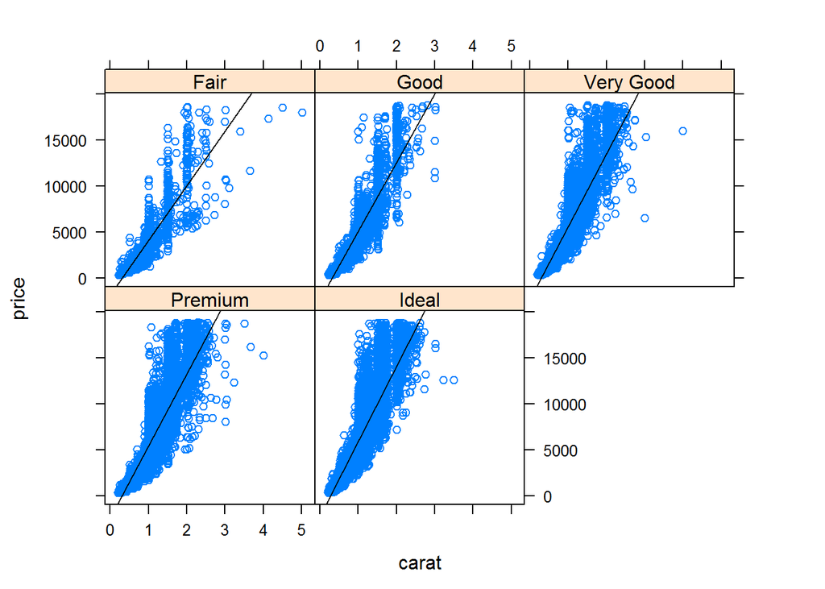

```r
library(lattice, quietly = TRUE)
library(ggplot2, quietly = TRUE)
xyplot(price ~ carat | cut,
data = diamonds,
panel = function(x, y, ...) {
panel.xyplot(x, y, ...)
lm1 <- lm(y ~ x)
panel.abline(a = lm1$coefficients[1],
b = lm1$coefficients[2])
},
as.table = TRUE)
```

[figure not shown]

```r
ggplot(data = diamonds, aes(x = diamonds$carat, y = diamonds$price))
```

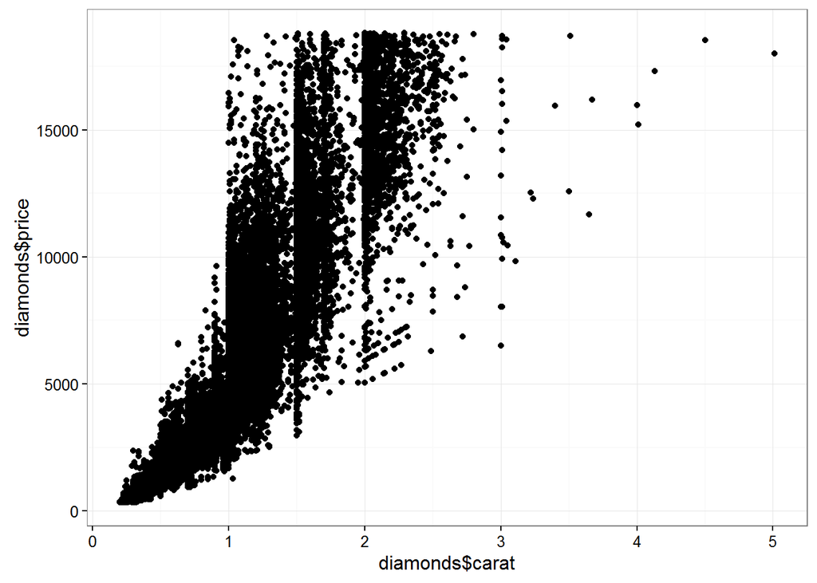

```r
ggplot(data = diamonds, aes(x = diamonds$carat, y = diamonds$price))+
      geom_point() +
      theme_bw()
```

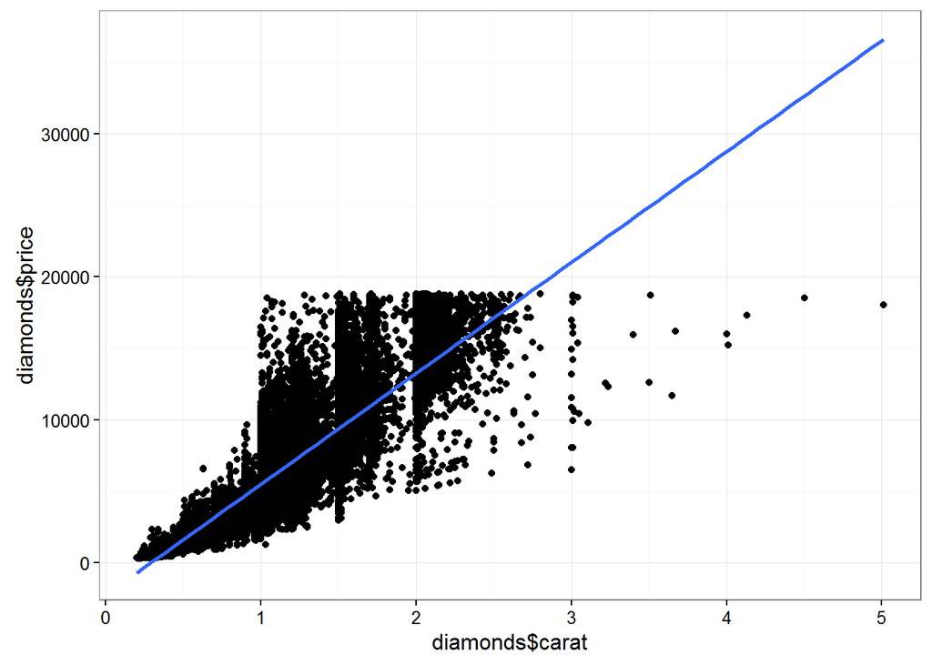

```r
ggplot(data = diamonds, aes(x = diamonds$carat, y = diamonds$price))+
      geom_point() +
      geom_smooth(method ="lm") +
      theme_bw()
```

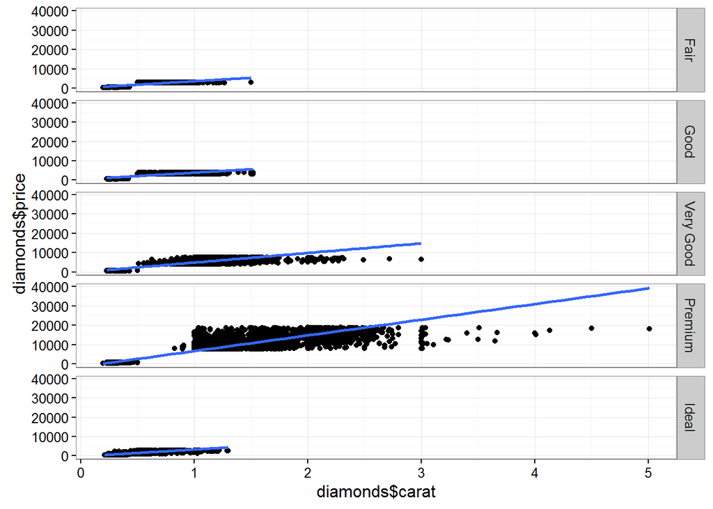

```r
t <- ggplot(data = diamonds, aes(x = diamonds$carat, y = diamonds$price))+
      geom_point()+
      geom_smooth(method ="lm")+
      theme_bw()

t + facet_grid(cut~ .)
```

```r
#qplot(diamonds$carat, diamonds$price)
```